# Grey Goose Sales

### Serving our Customers Better

We produce Grey Goose Vodka, the top super premium vodka brand in the United States. In being a super premium brand, our customer service should reflect this consideration by providing the right amount of merchandise for each of our retail sellers.

By looking at the stores in which Grey Goose is sold, we can clearly see there are five category of stores to cater to.

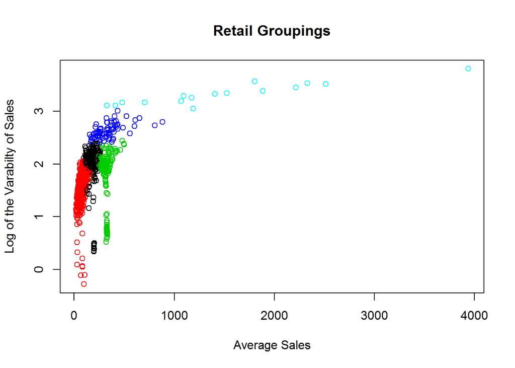

```
##   group VarofSales AverageSold
## 1     1  116.46090   169.91240
## 2     2   45.89681    77.77791
## 3     3   80.81233   313.45206
## 4     4  444.80176   338.46037
## 5     5 2405.73295  1504.64328
```

Group 1: Small and Variable  
Group 2: Small and Steady  
Group 3: Large and Steady  
Group 4: Large and Variable  
Group 5: Huge and Full attention

We need to focus on groups 1,4 and most importantly, 5.

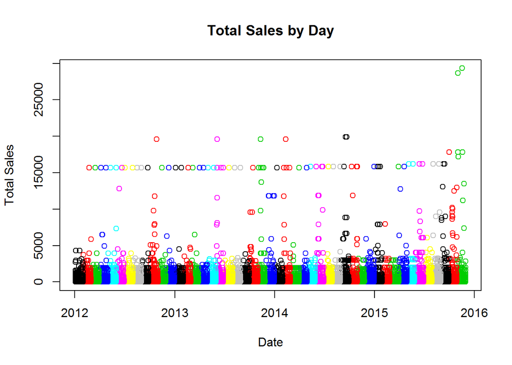

```
##
## Call:
## lm(formula = gg$TotalSales ~ gg$Month, data = gg)
##
## Residuals:
##     Min      1Q  Median      3Q     Max
##  -258.1  -169.7  -113.3     6.1 29090.4
##
## Coefficients:
##             Estimate Std. Error t value Pr(>|t|)
## (Intercept)  209.090      8.306  25.174  < 2e-16 ***
## gg$Month02     2.714     11.655   0.233  0.81587
## gg$Month03   -19.207     11.441  -1.679  0.09319 .
## gg$Month04    -0.386     11.253  -0.034  0.97263
## gg$Month05    -1.252     11.151  -0.112  0.91059
## gg$Month06    36.697     11.142   3.293  0.00099 ***
## gg$Month07   -12.570     11.018  -1.141  0.25390
## gg$Month08     8.884     11.170   0.795  0.42641
## gg$Month09    28.519     11.411   2.499  0.01244 *
## gg$Month10    56.269     11.192   5.028 4.98e-07 ***
## gg$Month11    28.256     11.680   2.419  0.01556 *
## gg$Month12     8.578     11.445   0.750  0.45355
## ---
## Signif. codes:  0 '***' 0.001 '**' 0.01 '*' 0.05 '.' 0.1 ' ' 1
##
## Residual standard error: 651.2 on 85311 degrees of freedom
## Multiple R-squared:  0.001066,   Adjusted R-squared:  0.0009371
## F-statistic: 8.275 on 11 and 85311 DF,  p-value: 1.069e-14
```